Python Code for Portfolio Optimization  
Chapter 14 – Robust Portfolios

Daniel P. Palomar (2025). [Portfolio Optimization: Theory and Application.](https://portfoliooptimizationbook.com/) Cambridge University Press.

Last update: November 1, 2026

Contributors:

- [Daniel Palomar](https://www.danielppalomar.com/)
- DeepSeek V4.1 Flash (DeepSeek, via [OpenCode](https://opencode.ai))

# Libraries

The following libraries are used in the examples:

```python
# Core numerical computing
import numpy as np
import pandas as pd
import warnings
warnings.filterwarnings('ignore')

# Financial data and performance metrics
import empyrical as emp

# Book data (pip install "git+https://github.com/dppalomar/pob.git#subdirectory=python")
from pob_python import SP500_stocks_2015to2020

# Plotting
import matplotlib.pyplot as plt
import seaborn as sns
sns.set_theme(style="darkgrid")
import plotly.io as pio
pio.renderers.default = "notebook"
pio.templates.default = "plotly_white"

# Optimization
import cvxpy as cp                     # interface for convex optimization solvers
from quadprog import solve_qp          # QP solver used for the mean-variance designs
from scipy.stats import chi2, gaussian_kde, norm  # statistical distributions
from tqdm.auto import tqdm             # progress bars
```

$\def\bm#1{\boldsymbol{#1}}$ $\def\textm#1{\textsf{#1}}$ $\def\T{{\mkern-2mu\raise-1mu\mathsf{T}}}$ $\def\R{\mathbb{R}}$ $\def\E{\rm I\kern-.2em E}$ $\def\w{\bm{w}}$ $\def\bmu{\bm{\mu}}$ $\def\bSigma{\bm{\Sigma}}$

# Helper functions

The notebook is organized around a single convention: **a portfolio design function receives a matrix of asset returns and returns a vector of portfolio weights**. This is the same signature that a backtest engine needs, so the very same functions can be used in the Monte Carlo experiments and in the backtests.

The *core* designs take the model parameters directly (e.g., `design_MVP(mu, Sigma)`), and the portfolio functions wrap them around the sample estimates (e.g., `MVP_naive(X)`). We start with the sample estimators:

```python
def compute_returns(prices: pd.DataFrame) -> pd.DataFrame:
    """
    Compute arithmetic returns from a price DataFrame.

    Parameters
    ----------
    prices : pd.DataFrame
        T x N DataFrame of asset prices.

    Returns
    -------
    pd.DataFrame
        (T - 1) x N DataFrame of arithmetic returns.
    """
    return prices.pct_change().dropna()


def estimate_parameters(X) -> tuple[np.ndarray, np.ndarray]:
    """
    Sample estimates of the mean vector and the covariance matrix.

    Parameters
    ----------
    X : array-like
        T x N matrix of asset returns.

    Returns
    -------
    mu : np.ndarray
        Length-N sample mean vector.
    Sigma : np.ndarray
        N x N sample covariance matrix (with ``ddof=1``, as R's ``cov``).
    """
    X = np.asarray(X, dtype=float)
    return X.mean(axis=0), np.cov(X.T)
```

The mean--variance portfolio (see [Chapter 7](https://bookdown.org/palomar/portfoliooptimizationbook/07-MPT.html)) is the workhorse of this chapter and the benchmark against which robustness is measured:

```python
def design_MVP(
        mu: np.ndarray,
        Sigma: np.ndarray,
        lambda_val: float = 1.0,
        reg: float = 1e-8,
) -> np.ndarray:
    """
    Design a mean-variance portfolio (MVP).

    Solves

        maximize    mu^T w - (lambda/2) w^T Sigma w
        subject to  w >= 0,  1^T w = 1.

    Parameters
    ----------
    mu : np.ndarray
        Length-N vector of expected returns.
    Sigma : np.ndarray
        N x N covariance matrix.
    lambda_val : float, default 1.0
        Risk-aversion parameter.
    reg : float, default 1e-8
        Tikhonov regularization, as a fraction of the mean diagonal of ``Sigma``,
        added to the quadratic term to keep the QP numerically well posed.

    Returns
    -------
    w : np.ndarray
        Length-N vector of portfolio weights.
    """
    n = len(mu)

    # # Solve the convex problem directly with CVXPY
    # w = cp.Variable(n)
    # objective = cp.Maximize(mu @ w - (lambda_val / 2) * cp.quad_form(w, cp.psd_wrap(Sigma)))
    # prob = cp.Problem(objective, [w >= 0, cp.sum(w) == 1])
    # prob.solve()
    # return w.value

    # Equivalent QP solved with quadprog (much faster, which matters in the
    # Monte Carlo experiments):
    #   minimize 1/2 w^T G w - a^T w   s.t.  C^T w >= b  (first meq columns of C are equalities)
    G = lambda_val * Sigma + reg * np.mean(np.diag(Sigma)) * np.eye(n)
    G = np.array(G, dtype=float)  # quadprog needs writable C-contiguous arrays
    a = np.array(mu, dtype=float)
    C = np.array(np.hstack([np.ones((n, 1)), np.eye(n)]), dtype=float)  # 1^T w = 1 and w >= 0
    b = np.array(np.concatenate([[1.0], np.zeros(n)]), dtype=float)
    return solve_qp(G, a, C, b, meq=1)[0]


def MVP_naive(X, lambda_val: float = 1.0) -> np.ndarray:
    """
    Naive mean-variance portfolio.

    Designs the mean-variance portfolio from the sample estimates of the mean
    vector and the covariance matrix of the given returns, ignoring the
    estimation error.

    Parameters
    ----------
    X : array-like
        T x N matrix of asset returns.
    lambda_val : float, default 1.0
        Risk-aversion parameter.

    Returns
    -------
    np.ndarray
        Length-N vector of portfolio weights.
    """
    mu_hat, Sigma_hat = estimate_parameters(X)
    return design_MVP(mu_hat, Sigma_hat, lambda_val=lambda_val)
```

The key numerical experiment of this chapter consists of drawing synthetic samples from a Gaussian model $\mathcal{N}(\hat{\bmu},\hat{\bSigma})$, designing a portfolio from each such "noisy" sample, and then evaluating the resulting portfolios on the (assumed) true parameters. The following engine does exactly that, and shares the same noise realization across all the designs so that they can be compared fairly:

```python
def monte_carlo_estimation_error(
        design_funs: dict[str, callable],
        mu: np.ndarray,
        Sigma: np.ndarray,
        T: int,
        num_realizations: int = 1000,
        seed: int = 42,
        verbose: bool = True,
) -> dict[str, np.ndarray]:
    """
    Monte Carlo study of the sensitivity to estimation errors.

    For each realization, a synthetic sample of ``T`` observations is drawn from
    N(mu, Sigma) and every design function is applied to the same sample, so that
    the differences between designs are not contaminated by different noise.

    Parameters
    ----------
    design_funs : dict[str, callable]
        Mapping from a method name to a function that takes a T x N matrix of
        (noisy) returns and returns a length-N weight vector.
    mu : np.ndarray
        True mean vector of the Gaussian model.
    Sigma : np.ndarray
        True covariance matrix of the Gaussian model.
    T : int
        Number of observations of each synthetic sample (the lookback length).
    num_realizations : int, default 1000
        Number of Monte Carlo realizations.
    seed : int, default 42
        Seed of the random number generator.
    verbose : bool, default True
        If True, show a progress bar.

    Returns
    -------
    dict[str, np.ndarray]
        Mapping from a method name to a ``num_realizations x N`` matrix of weights.
    """
    rng = np.random.default_rng(seed)
    Sigma = 0.5 * (Sigma + Sigma.T)  # enforce symmetry for multivariate_normal
    n = len(mu)
    ws = {name: np.zeros((num_realizations, n)) for name in design_funs}

    for b in tqdm(range(num_realizations), disable=not verbose):
        X_noisy = rng.multivariate_normal(mu, Sigma, size=T)
        for name, fun in design_funs.items():
            ws[name][b] = np.asarray(fun(X_noisy), dtype=float)

    return ws


def mean_variance_value(w: np.ndarray, mu: np.ndarray, Sigma: np.ndarray) -> float:
    """Mean-variance objective value mu^T w - (1/2) w^T Sigma w."""
    return float(w @ mu - 0.5 * w @ Sigma @ w)


def sharpe_ratio(w: np.ndarray, mu: np.ndarray, Sigma: np.ndarray) -> float:
    """Sharpe ratio (no risk-free rate) of a portfolio under the model parameters."""
    return float((w @ mu) / np.sqrt(w @ Sigma @ w))


def evaluate_portfolios(
        ws: dict[str, np.ndarray],
        mu: np.ndarray,
        Sigma: np.ndarray,
) -> pd.DataFrame:
    """
    Evaluate a collection of portfolio realizations.

    Parameters
    ----------
    ws : dict[str, np.ndarray]
        Mapping from a method name to a ``num_realizations x N`` matrix of weights.
    mu : np.ndarray
        True mean vector used to evaluate the portfolios.
    Sigma : np.ndarray
        True covariance matrix used to evaluate the portfolios.

    Returns
    -------
    pd.DataFrame
        Tidy (long-format) DataFrame with one row per (method, realization) and
        columns ``method``, ``realization``, ``mean-variance`` and ``Sharpe ratio``.
    """
    rows = []
    for name, W in ws.items():
        rows.append(pd.DataFrame({
            "method": name,
            "realization": np.arange(1, len(W) + 1),
            "mean-variance": [mean_variance_value(w, mu, Sigma) for w in W],
            "Sharpe ratio": [sharpe_ratio(w, mu, Sigma) for w in W],
        }))

    df = pd.concat(rows, ignore_index=True)
    df["method"] = pd.Categorical(df["method"], categories=list(ws), ordered=True)
    return df
```

The two plotting functions required repeatedly are a grouped bar chart of the weights across realizations (the book's "portfolio for different estimation errors" figures) and a ridgeline plot of the empirical distribution of a performance metric (the book's `geom_density_ridges` figures). Note that the Monte Carlo and backtest helpers accept `verbose=True` to display a progress bar; we silence it in the notebook calls to keep the rendered output compact:

```python
def plot_weights(
        ws: np.ndarray,
        assets: list[str],
        title: str = "Portfolio for different estimation errors",
        ax: plt.Axes | None = None,
) -> None:
    """
    Grouped bar chart of the portfolio weights across realizations.

    Parameters
    ----------
    ws : np.ndarray
        ``num_realizations x N`` matrix of weights, one row per realization.
    assets : list[str]
        Length-N list of asset names.
    title : str, default 'Portfolio for different estimation errors'
        Title of the plot.
    ax : plt.Axes or None, default None
        Axes where to draw the plot. If None, a new figure is created.
    """
    df = pd.DataFrame(
        np.asarray(ws).T,
        index=assets,
        columns=[f"#{i + 1}" for i in range(len(ws))],
    )

    own_figure = ax is None
    if own_figure:
        _, ax = plt.subplots(figsize=(12, 4))

    df.plot(kind="bar", ax=ax, width=0.85, edgecolor="black", linewidth=0.4)
    ax.set_title(title, fontsize=11)
    ax.set_xlabel(None)
    ax.set_ylabel("weight")
    ax.tick_params(axis="x", rotation=0, labelsize=8)
    ax.legend(title="realization", ncol=len(df.columns), fontsize=8, title_fontsize=8)

    if own_figure:
        plt.tight_layout()
        plt.show()


def plot_distribution(
        df: pd.DataFrame,
        x: str,
        title: str,
        xlim: tuple[float | None, float | None] | None = None,
        reference: float | None = None,
        reference_label: str = "clairvoyant portfolio",
        bw_method: float | str | None = None,
) -> None:
    """
    Ridgeline plot of the empirical distribution of a performance metric.

    Each method is drawn on its own baseline (as in the book's
    ``geom_density_ridges`` figures), with the densities shifted vertically so
    that they overlap partially.

    Parameters
    ----------
    df : pd.DataFrame
        Tidy DataFrame produced by ``evaluate_portfolios``.
    x : str
        Name of the column containing the metric to plot.
    title : str
        Title of the plot.
    xlim : tuple or None, default None
        Limits of the x-axis (``None`` leaves the corresponding limit free).
    reference : float or None, default None
        Value to mark with a vertical line (e.g., the clairvoyant portfolio).
    reference_label : str, default 'clairvoyant portfolio'
        Label of the reference line.
    bw_method : float, str or None, default None
        Bandwidth of the Gaussian kernel density estimate.
    """
    methods = list(df["method"].cat.categories)
    n_methods = len(methods)
    colors = sns.color_palette("deep", n_methods)

    # Grid where the densities are evaluated
    values = df[x].to_numpy()
    grid = np.linspace(np.nanmin(values), np.nanmax(values), 500)
    densities = {
        name: gaussian_kde(df.loc[df["method"] == name, x].to_numpy(), bw_method=bw_method)(grid)
        for name in methods
    }
    max_density = max(d.max() for d in densities.values())

    # Vertical offsets: the first method is drawn on top
    offsets = np.arange(n_methods)[::-1]

    _, ax = plt.subplots(figsize=(9, 1.0 + 0.85 * n_methods))
    for k, name in enumerate(methods):
        y = offsets[k] + 0.9 * densities[name] / max_density
        ax.fill_between(grid, offsets[k], y, alpha=0.6, color=colors[k],
                        edgecolor="black", linewidth=1.0)

    if reference is not None:
        ax.axvline(reference, color="black", linestyle="--", linewidth=1.2,
                   label=reference_label)
        ax.legend(loc="upper right", fontsize=8)

    ax.set_yticks(offsets)
    ax.set_yticklabels(methods, fontsize=9)
    ax.set_ylim(-0.2, n_methods)
    if xlim is not None:
        ax.set_xlim(xlim[0], xlim[1])

    ax.set_title(title)
    ax.set_xlabel(x)
    ax.set_ylabel(None)
    plt.tight_layout()
    plt.show()
```

Next, the walk-forward backtest engine. At each point in time the design functions receive the last `lookback` returns, portfolios are re-optimized every `optimize_every` periods, and rebalanced every `rebalance_every` periods (in between rebalancing dates the weights drift with the realized returns):

```python
def backtest(
        portfolio_funcs: dict[str, callable],
        prices: pd.DataFrame,
        lookback: int,
        optimize_every: int = 21,
        rebalance_every: int = 1,
        verbose: bool = True,
) -> tuple[pd.DataFrame, dict[str, pd.DataFrame]]:
    """
    Walk-forward backtest of several portfolio designs.

    Parameters
    ----------
    portfolio_funcs : dict[str, callable]
        Mapping from a strategy name to a function that takes a
        ``lookback x N`` matrix of returns and returns a length-N weight vector.
    prices : pd.DataFrame
        T x N DataFrame of asset prices.
    lookback : int
        Number of past returns used to design the portfolios.
    optimize_every : int, default 21
        Number of periods between re-optimizations.
    rebalance_every : int, default 1
        Number of periods between rebalancings to the latest target weights.
    verbose : bool, default True
        If True, print the re-optimization dates.

    Returns
    -------
    returns : pd.DataFrame
        (T - lookback) x K DataFrame of out-of-sample portfolio returns.
    weights : dict[str, pd.DataFrame]
        Mapping from a strategy name to a (T - lookback) x N DataFrame of weights.
    """
    if optimize_every % rebalance_every != 0:
        raise ValueError("optimize_every must be a multiple of rebalance_every")

    X = compute_returns(prices)
    rets = X.values
    T, N = X.shape
    portf_rets = {name: np.full(T, np.nan) for name in portfolio_funcs}
    all_w = {name: np.full((T, N), np.nan) for name in portfolio_funcs}

    for name, fun in portfolio_funcs.items():
        current_w = np.zeros(N)
        target_w = np.zeros(N)

        for t in range(lookback, T):
            if (t - lookback) % rebalance_every == 0:
                if (t - lookback) % optimize_every == 0:
                    target_w = np.asarray(fun(X.iloc[t - lookback:t]), dtype=float)
                    if verbose:
                        print(f"  Re-optimizing '{name}' at {X.index[t].date()}")
                current_w = target_w.copy()

            all_w[name][t] = current_w
            portf_rets[name][t] = rets[t] @ current_w

            # drift the weights with the realized returns
            current_w = current_w * (1 + rets[t])
            current_w = current_w / current_w.sum()

    returns = pd.DataFrame(portf_rets, index=X.index).iloc[lookback:]
    weights = {
        name: pd.DataFrame(w, index=X.index, columns=prices.columns).iloc[lookback:]
        for name, w in all_w.items()
    }
    return returns, weights


def plot_backtest(returns: pd.DataFrame, title: str | None = None) -> None:
    """
    Cumulative P&L (top panel) and drawdown (bottom panel) of each portfolio.

    Parameters
    ----------
    returns : pd.DataFrame
        T x K DataFrame of portfolio returns.
    title : str or None, default None
        Optional suptitle of the figure.
    """
    NAV = (1 + returns).cumprod()
    drawdown = NAV / NAV.cummax() - 1

    _, axes = plt.subplots(2, 1, figsize=(12, 7), sharex=True)
    NAV.plot(ax=axes[0], linewidth=1.1)
    axes[0].set_title("Cumulative P&L")
    axes[0].set_ylabel("wealth")
    axes[0].set_xlabel(None)
    axes[0].legend(title=None, fontsize=8)

    drawdown.plot(ax=axes[1], linewidth=1.1)
    axes[1].set_title("Drawdown")
    axes[1].set_ylabel("drawdown")
    axes[1].set_xlabel(None)
    axes[1].legend(title=None, fontsize=8)

    if title is not None:
        plt.suptitle(title)

    plt.tight_layout()
    plt.show()


def performance_metrics(returns: pd.DataFrame) -> pd.DataFrame:
    """
    Summary performance statistics of each portfolio.

    Parameters
    ----------
    returns : pd.DataFrame
        T x K DataFrame of daily portfolio returns.

    Returns
    -------
    pd.DataFrame
        K x 4 DataFrame with the annualized return, annualized volatility,
        Sharpe ratio and maximum drawdown of each portfolio.
    """
    return pd.DataFrame({
        "annual return": returns.apply(emp.annual_return),
        "annual volatility": returns.apply(emp.annual_volatility),
        "Sharpe ratio": returns.apply(emp.sharpe_ratio),
        "max drawdown": returns.apply(emp.max_drawdown),
    })
```

Finally, to assess the backtests beyond a single dataset, we resample the financial data (random subset of assets and random contiguous time window) and run the same backtest on each resampled dataset:

```python
def financial_data_resample(
        prices: pd.DataFrame,
        num_datasets: int = 100,
        N_sample: int = 50,
        T_sample: int = 252,
        seed: int = 42,
) -> list[pd.DataFrame]:
    """
    Generate resampled price datasets.

    Each dataset is built from a random subset of ``N_sample`` assets and a random
    contiguous time window of ``T_sample`` observations.

    Parameters
    ----------
    prices : pd.DataFrame
        T x N DataFrame of asset prices.
    num_datasets : int, default 100
        Number of resampled datasets.
    N_sample : int, default 50
        Number of assets of each dataset.
    T_sample : int, default 252
        Number of observations of each dataset.
    seed : int, default 42
        Seed of the random number generator.

    Returns
    -------
    list[pd.DataFrame]
        List of resampled price DataFrames.
    """
    rng = np.random.default_rng(seed)
    datasets = []

    for _ in range(num_datasets):
        cols = np.sort(rng.choice(prices.shape[1], size=N_sample, replace=False))
        start = rng.integers(0, prices.shape[0] - T_sample)
        datasets.append(prices.iloc[start:start + T_sample, cols])

    return datasets


def multiple_backtests(
        portfolio_funcs: dict[str, callable],
        datasets: list[pd.DataFrame],
        lookback: int,
        optimize_every: int = 21,
        rebalance_every: int = 1,
        verbose: bool = True,
) -> pd.DataFrame:
    """
    Run the same walk-forward backtest on each resampled dataset.

    Parameters
    ----------
    portfolio_funcs : dict[str, callable]
        Mapping from a strategy name to a portfolio design function.
    datasets : list[pd.DataFrame]
        List of price DataFrames.
    lookback : int
        Number of past returns used to design the portfolios.
    optimize_every : int, default 21
        Number of periods between re-optimizations.
    rebalance_every : int, default 1
        Number of periods between rebalancings.
    verbose : bool, default True
        If True, show a progress bar.

    Returns
    -------
    pd.DataFrame
        Tidy DataFrame with one row per (dataset, method) and columns
        ``dataset``, ``method``, ``Sharpe ratio`` and ``max drawdown``.
    """
    rows = []

    for i, prices in enumerate(tqdm(datasets, disable=not verbose)):
        returns, _ = backtest(portfolio_funcs, prices, lookback=lookback,
                              optimize_every=optimize_every,
                              rebalance_every=rebalance_every, verbose=False)
        for name in returns.columns:
            rows.append({
                "dataset": i + 1,
                "method": name,
                "Sharpe ratio": emp.sharpe_ratio(returns[name]),
                "max drawdown": emp.max_drawdown(returns[name]),
            })

    perf = pd.DataFrame(rows)
    perf["method"] = pd.Categorical(perf["method"], categories=list(portfolio_funcs), ordered=True)
    return perf


def plot_performance_boxplots(
        perf: pd.DataFrame,
        metrics: tuple[str, ...] = ("Sharpe ratio", "max drawdown"),
) -> None:
    """
    Box plots of the out-of-sample performance metrics across resampled datasets.

    Parameters
    ----------
    perf : pd.DataFrame
        Tidy DataFrame produced by ``multiple_backtests``.
    metrics : tuple[str, ...]
        Names of the performance metrics to plot.
    """
    _, axes = plt.subplots(1, len(metrics), figsize=(11, 3.2))

    for ax, metric in zip(np.atleast_1d(axes), metrics):
        sns.boxplot(data=perf, x="method", y=metric, ax=ax, width=0.5, color="#4C72B0")
        ax.set_title(metric)
        ax.set_xlabel(None)
        ax.tick_params(axis="x", rotation=15, labelsize=8)

    plt.tight_layout()
    plt.show()
```

# Introduction

Markowitz's mean--variance portfolio optimization balances the expected return $\w^\T\bmu$ against the risk measured by the variance $\w^\T\bSigma\w$: $$ \begin{array}{ll} \underset{\w}{\textm{maximize}} & \w^\T\bmu - \frac{\lambda}{2}\w^\T\bSigma\w\\ \textm{subject to} & \w \in \mathcal{W}, \end{array} $$ where $\bmu$ and $\bSigma$ are the parameters, $\lambda$ controls the investor's risk aversion, and $\mathcal{W}$ denotes a constraint set such as $\{\w \mid \bm{1}^\T\w=1, \w\ge\bm{0} \}$.

In practice, $\bmu$ and $\bSigma$ are estimated from historical data, which introduces estimation errors due to the limited amount of data and the lack of stationarity. This noise, especially in $\hat{\bmu}$, leads to erratic portfolio designs, a problem known as the "Markowitz optimization enigma" [@Michaud1989]: portfolio optimization problems are "estimation-error maximizers" and the resulting "optimal" portfolios are financially meaningless.

The next figure illustrates the sensitivity of the mean--variance portfolio to the estimation errors: we take ten stocks from 2019 onwards, draw six synthetic samples from the Gaussian model fitted to the data, design the mean--variance portfolio for each sample, and plot the six resulting portfolios. The sizes of the positions jump around wildly from one realization to another, which is unacceptable from a practical standpoint.

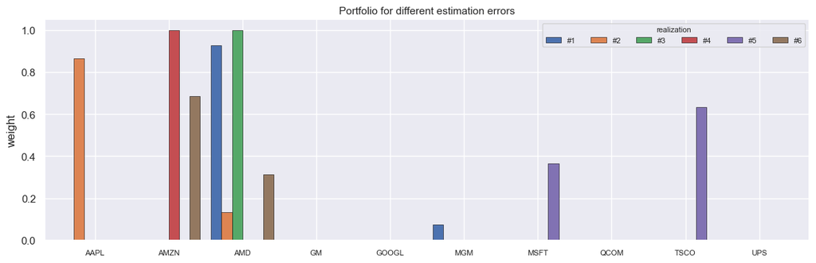

```python
# Ten liquid stocks from 2019 onwards
tickers = ["AAPL", "AMZN", "AMD", "GM", "GOOGL", "MGM", "MSFT", "QCOM", "TSCO", "UPS"]
stock_prices = SP500_stocks_2015to2020[tickers].loc["2019":]
X = compute_returns(stock_prices)
mu, Sigma = estimate_parameters(X)

# Six realizations of the estimation error
ws = monte_carlo_estimation_error(
    design_funs={"Naive MVP": MVP_naive},
    mu=mu, Sigma=Sigma, T=len(X),
    num_realizations=6, seed=42, verbose=False,
)["Naive MVP"]

plot_weights(ws, assets=list(stock_prices.columns))
```

# Robust worst-case portfolio optimization

To isolate the effect of the uncertainty in $\bmu$, we consider the global maximum return portfolio (GMRP) for an estimated mean vector $\hat{\bmu}$: $$ \begin{array}{ll} \underset{\w}{\textm{maximize}} & \w^\T\hat{\bmu}\\ \textm{subject to} & \bm{1}^\T\w=1, \quad \w\ge\bm{0}, \end{array} $$ which is known to be terribly sensitive to estimation errors. Instead, we use the worst-case formulation $$ \begin{array}{ll} \underset{\w}{\textm{maximize}} & \underset{\bmu \in \mathcal{U}_{\bmu}}{\textm{inf}} \; \w^\T\bmu\\ \textm{subject to} & \bm{1}^\T\w=1, \quad \w\ge\bm{0}, \end{array} $$ where the typical choices for the uncertainty region $\mathcal{U}_{\bmu}$ are the ellipsoidal and box sets considered next.

## Ellipsoidal uncertainty set

The ellipsoidal uncertainty set for $\bmu$ is $$ \mathcal{U}_{\bmu} = \left\{\bmu = \hat{\bmu} + \kappa \bm{S}^{1/2}\bm{u} \mid \|\bm{u}\|_2 \le 1\right\}, $$ where $\bm{S}^{1/2}$ is the symmetric square-root matrix of the shape $\bm{S}$, e.g., $\bm{S}=(1/T)\bSigma$, and $\kappa$ determines the size of the ellipsoid.

The corresponding worst-case value of $\w^\T\bmu$ is $$ \begin{aligned} \underset{\bmu \in \mathcal{U}_{\bmu}}{\textm{inf}} \; \w^\T\bmu &= \w^\T\hat{\bmu} - \kappa\; \|\bm{S}^{1/2}\w\|_2. \end{aligned} $$

## Box uncertainty set

The box uncertainty set for $\bmu$ is $$ \mathcal{U}_{\bmu} = \left\{\bmu \mid -\bm{\delta} \le \bmu - \hat{\bmu} \le \bm{\delta}\right\}, $$ where $\bm{\delta}$ is the half-width of the box in all dimensions.

The corresponding worst-case value of $\w^\T\bmu$ is $$ \begin{aligned} \underset{\bmu \in \mathcal{U}_{\bmu}}{\textm{inf}} \; \w^\T\bmu &= \w^\T\hat{\bmu} - |\w|^\T\bm{\delta}. \end{aligned} $$

## Numerical experiments

### Sensitivity

First, let's write the code for the robust mean--variance formulations with ellipsoidal and box uncertainty sets for the mean vector. Both designs simply replace the expected return $\w^\T\hat{\bmu}$ by its worst-case value inside the mean--variance objective, which preserves convexity: the ellipsoidal version is a second-order cone program, while the box version is a plain quadratic program (since $\w\ge\bm{0}$ implies $|\w|=\w$).

```python
def design_MVP_robust_mu_box(
        mu_hat: np.ndarray,
        delta: np.ndarray,
        Sigma_hat: np.ndarray,
        lambda_val: float = 1.0,
) -> np.ndarray:
    """
    Robust mean-variance portfolio under a box uncertainty set for the mean.

    Solves

        maximize    w^T mu_hat - |w|^T delta - (lambda/2) w^T Sigma_hat w
        subject to  w >= 0,  1^T w = 1.

    Parameters
    ----------
    mu_hat : np.ndarray
        Length-N vector of estimated expected returns.
    delta : np.ndarray
        Length-N vector with the half-widths of the box.
    Sigma_hat : np.ndarray
        N x N estimated covariance matrix.
    lambda_val : float, default 1.0
        Risk-aversion parameter.

    Returns
    -------
    w : np.ndarray
        Length-N vector of portfolio weights.
    """
    n = len(mu_hat)
    w = cp.Variable(n)
    objective = cp.Maximize(
        mu_hat @ w
        - cp.sum(cp.multiply(cp.abs(w), delta))
        - (lambda_val / 2) * cp.quad_form(w, cp.psd_wrap(Sigma_hat))
    )
    prob = cp.Problem(objective, [w >= 0, cp.sum(w) == 1])
    prob.solve()
    return w.value


def design_MVP_robust_mu_ellipsoid(
        mu_hat: np.ndarray,
        Sigma_hat: np.ndarray,
        kappa_mu: float = 0.1,
        S_mu: np.ndarray | None = None,
        lambda_val: float = 1.0,
) -> np.ndarray:
    """
    Robust mean-variance portfolio under an ellipsoidal uncertainty set for the mean.

    Solves

        maximize    w^T mu_hat - kappa ||S^{1/2} w||_2 - (lambda/2) w^T Sigma_hat w
        subject to  w >= 0,  1^T w = 1,

    where S is the shape matrix of the ellipsoid (by default S = Sigma_hat).

    Parameters
    ----------
    mu_hat : np.ndarray
        Length-N vector of estimated expected returns.
    Sigma_hat : np.ndarray
        N x N estimated covariance matrix (used for the risk term).
    kappa_mu : float, default 0.1
        Size of the ellipsoid (radius of the uncertainty set).
    S_mu : np.ndarray or None, default None
        N x N shape matrix of the ellipsoid. If None, ``Sigma_hat`` is used.
    lambda_val : float, default 1.0
        Risk-aversion parameter.

    Returns
    -------
    w : np.ndarray
        Length-N vector of portfolio weights.
    """
    if S_mu is None:
        S_mu = Sigma_hat

    n = len(mu_hat)
    S12 = np.linalg.cholesky(S_mu)  # lower triangular with S12 @ S12.T = S_mu
    w = cp.Variable(n)
    objective = cp.Maximize(
        mu_hat @ w
        - kappa_mu * cp.norm(S12.T @ w, 2)
        - (lambda_val / 2) * cp.quad_form(w, cp.psd_wrap(Sigma_hat))
    )
    prob = cp.Problem(objective, [w >= 0, cp.sum(w) == 1])
    prob.solve()
    return w.value


def MVP_robust_mu_box(X, kappa_mu: float = 0.2, lambda_val: float = 1.0) -> np.ndarray:
    """
    Robust mean-variance portfolio with a box uncertainty set for the mean.

    The half-widths of the box are set to ``kappa_mu`` times the standard
    deviations of the assets.

    Parameters
    ----------
    X : array-like
        T x N matrix of asset returns.
    kappa_mu : float, default 0.2
        Size of the box uncertainty set.
    lambda_val : float, default 1.0
        Risk-aversion parameter.

    Returns
    -------
    np.ndarray
        Length-N vector of portfolio weights.
    """
    mu_hat, Sigma_hat = estimate_parameters(X)
    delta = kappa_mu * np.sqrt(np.diag(Sigma_hat))
    return design_MVP_robust_mu_box(mu_hat, delta, Sigma_hat, lambda_val=lambda_val)


def MVP_robust_mu_ellipsoid(X, kappa_mu: float = 0.2, lambda_val: float = 1.0) -> np.ndarray:
    """
    Robust mean-variance portfolio with an ellipsoidal uncertainty set for the mean.

    Parameters
    ----------
    X : array-like
        T x N matrix of asset returns.
    kappa_mu : float, default 0.2
        Size of the ellipsoidal uncertainty set.
    lambda_val : float, default 1.0
        Risk-aversion parameter.

    Returns
    -------
    np.ndarray
        Length-N vector of portfolio weights.
    """
    mu_hat, Sigma_hat = estimate_parameters(X)
    return design_MVP_robust_mu_ellipsoid(mu_hat, Sigma_hat, kappa_mu=kappa_mu,
                                          lambda_val=lambda_val)
```

We can now observe the improved stability of the robust mean--variance portfolios: the three panels below correspond to the naive design, the box uncertainty set ($\delta = 0.5$ times the standard deviations), and the ellipsoidal uncertainty set ($\kappa = 0.5$), all over the same six realizations of the estimation error.

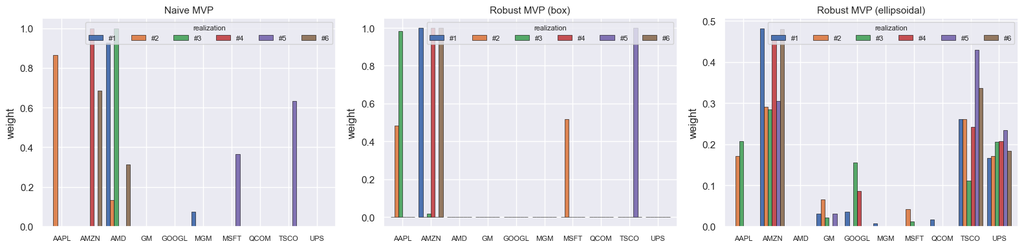

```python
# Same ten stocks as in the introduction
stock_prices = SP500_stocks_2015to2020[tickers].loc["2019":]
X = compute_returns(stock_prices)
mu, Sigma = estimate_parameters(X)

ws = monte_carlo_estimation_error(
    design_funs={
        "Naive MVP": MVP_naive,
        "Robust MVP (box)": lambda X: MVP_robust_mu_box(X, kappa_mu=0.5),
        "Robust MVP (ellipsoidal)": lambda X: MVP_robust_mu_ellipsoid(X, kappa_mu=0.5),
    },
    mu=mu, Sigma=Sigma, T=len(X),
    num_realizations=6, seed=42, verbose=False,
)

_, axes = plt.subplots(1, 3, figsize=(16, 4))
for ax, (name, W) in zip(axes, ws.items()):
    plot_weights(W, assets=list(stock_prices.columns), title=name, ax=ax)
plt.tight_layout()
plt.show()
```

### Naive versus robust portfolios

We now compute the empirical distribution of the achieved mean--variance objective, as well as the Sharpe ratio, over 1,000 Monte Carlo realizations with $N=50$ stocks. The robust designs avoid the worst-case realizations (the left tail of the distributions) at the expense of not achieving the best-case realizations (the right tail); they are more stable and robust, as expected.

```python
# Parameters
num_realizations = 1000
N = 50
lookback_months = 12
T_lookback = lookback_months * 21

# Random subset of 50 stocks from 2019 onwards
rng = np.random.default_rng(42)
cols = np.sort(rng.choice(SP500_stocks_2015to2020.shape[1], size=N, replace=False))
stock_prices = SP500_stocks_2015to2020.iloc[:, cols].loc["2019":]

# "True" parameters of the Gaussian model, estimated on the first training window
X_train = compute_returns(stock_prices).iloc[:T_lookback]
mu_true, Sigma_true = estimate_parameters(X_train)
w_clairvoyant = design_MVP(mu_true, Sigma_true, lambda_val=1)

# Monte Carlo over estimation-error realizations
design_funs = {
    "Naive MVP": MVP_naive,
    "Robust MVP (box uncertainty set)": MVP_robust_mu_box,
    "Robust MVP (ellipsoidal uncertainty set)": MVP_robust_mu_ellipsoid,
}

ws = monte_carlo_estimation_error(design_funs, mu_true, Sigma_true, T=len(X_train),
                                  num_realizations=num_realizations, seed=42, verbose=False)
df = evaluate_portfolios(ws, mu_true, Sigma_true)
```

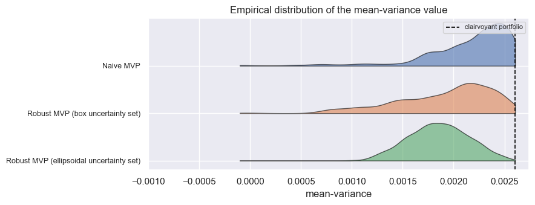

```python
plot_distribution(
    df, x="mean-variance",
    title="Empirical distribution of the mean-variance value",
    xlim=(-0.001, None),
    reference=mean_variance_value(w_clairvoyant, mu_true, Sigma_true),
)
```

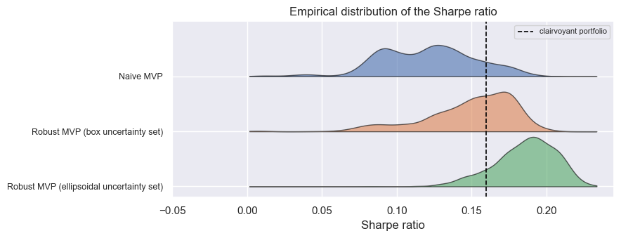

```python
plot_distribution(
    df, x="Sharpe ratio",
    title="Empirical distribution of the Sharpe ratio",
    xlim=(-0.05, None),
    reference=sharpe_ratio(w_clairvoyant, mu_true, Sigma_true),
)
```

### Backtests

Let's now backtest the naive and robust mean--variance portfolios on real data (50 stocks from 2017 onwards, six-month lookback, re-optimization every month, daily rebalancing):

```python
N = 50
lookback_months = 6
rng = np.random.default_rng(42)
cols = np.sort(rng.choice(SP500_stocks_2015to2020.shape[1], size=N, replace=False))
stock_prices = SP500_stocks_2015to2020.iloc[:, cols].loc["2017":]

portfolio_funcs = {
    "Naive MVP": MVP_naive,
    "Robust MVP (box uncertainty set)": MVP_robust_mu_box,
    "Robust MVP (ellipsoidal uncertainty set)": MVP_robust_mu_ellipsoid,
}

returns, weights = backtest(
    portfolio_funcs,
    prices=stock_prices,
    lookback=lookback_months * 21,
    optimize_every=21,
    rebalance_every=1,
    verbose=False,
)
```

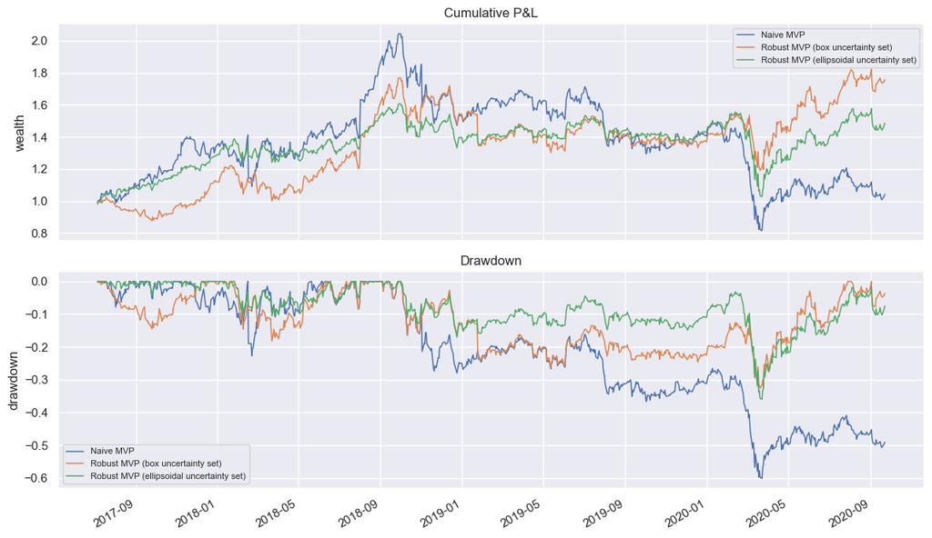

```python
plot_backtest(returns)
```

```python
performance_metrics(returns).style.format({
    "annual return": "{:.2%}",
    "annual volatility": "{:.2%}",
    "Sharpe ratio": "{:.2f}",
    "max drawdown": "{:.2%}",
})
```

|  | annual return | annual volatility | Sharpe ratio | max drawdown |
| --- | --- | --- | --- | --- |
| Naive MVP | 1.29% | 36.26% | 0.22 | -60.10% |
| Robust MVP (box uncertainty set) | 19.18% | 28.57% | 0.76 | -32.65% |
| Robust MVP (ellipsoidal uncertainty set) | 13.12% | 24.35% | 0.63 | -35.97% |

To be more exhaustive, we now run multiple backtests of the naive versus the robust mean--variance portfolios on 100 resampled datasets (50 random stocks over a random 12-month window, six-month lookback), and compare the distributions of the out-of-sample Sharpe ratio and maximum drawdown:

```python
datasets = financial_data_resample(
    SP500_stocks_2015to2020,
    num_datasets=100, N_sample=50, T_sample=12 * 21, seed=42,
)

perf = multiple_backtests(
    portfolio_funcs,
    datasets=datasets,
    lookback=6 * 21,
    optimize_every=21,
    rebalance_every=1,
    verbose=False,
)
```

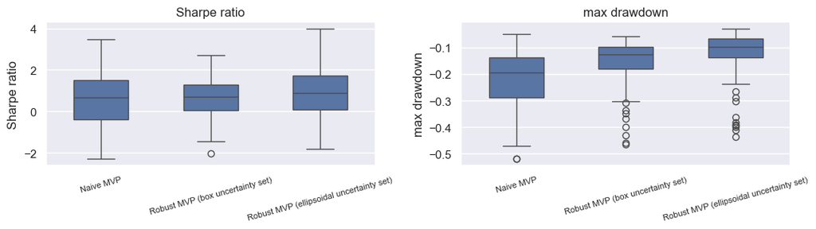

```python
plot_performance_boxplots(perf)
```

# Portfolio resampling

## Resampling methods

Estimating a parameter $\bm{\theta}$ with $\hat{\bm{\theta}}$ is insufficient without knowing the accuracy of the estimate. Confidence intervals traditionally provide this accuracy but rely heavily on theoretical mathematics. Resampling methods, such as cross-validation and the bootstrap, use computer-based techniques to assess statistical accuracy without complex formulas [@EfronTibshirani1993].

The **bootstrap**, introduced by Efron in 1979, mimics the original sampling process by resampling the observed data with replacement to create multiple bootstrap samples. Each sample leads to a different realization of the estimate, $\hat{\bm{\theta}}^{*(b)}$, from which accuracy measures (bias, variance, confidence intervals) are empirically derived. The statistical behavior of $\hat{\bm{\theta}}^{*(b)}$ faithfully represents that of $\hat{\bm{\theta}}$ compared to the true parameter $\bm{\theta}$, especially as the number of resamples $B$ increases [@EfronTibshirani1993].

To be more precise, the original $n$ observations $\bm{x}_1,\dots,\bm{x}_n$ are sampled $n$ times with replacement (some samples will be selected multiple times while others will not be used). This procedure is repeated $B$ times to obtain the bootstrap samples, $$ \big(\bm{x}_1,\dots,\bm{x}_n\big) \rightarrow \left(\bm{x}_1^{*(b)},\dots,\bm{x}_n^{*(b)}\right), \quad b=1,\dots,B, $$ each of which leads to a different realization of the estimation (bootstrap replicates), $$ \hat{\bm{\theta}}^{*(b)} = f\left(\bm{x}_1^{*(b)},\dots,\bm{x}_n^{*(b)}\right), \quad b=1,\dots,B, $$ from which measures of accuracy of the estimator (bias, variance, confidence intervals, etc.) can then be empirically obtained.

The key theoretical result is that the statistical behavior of the random resampled estimates $\hat{\bm{\theta}}^{*(b)}$ compared to $\hat{\bm{\theta}}$ (taken as the true parameter) faithfully represents the statistics of the random estimates $\hat{\bm{\theta}}$ compared to the true (unknown) parameter $\bm{\theta}$; the accuracy estimates are asymptotically consistent as $B\rightarrow\infty$ (under some technical conditions) [@EfronTibshirani1993]. This is a rather surprising result that allows the empirical assessment of the accuracy of an estimator without having access to the true parameter $\bm{\theta}$.

We now illustrate the magic of the bootstrap to estimate the accuracy of the sample mean estimator (from $n=100$ observations). The empirical distribution of the bias of the estimator, computed via $B=1{,}000$ bootstraps, is an accurate approximation of the true distribution.

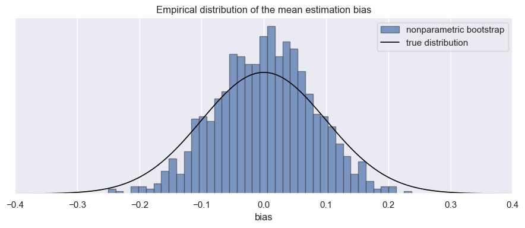

```python
B = 1000  # number of bootstraps
n = 100   # number of observations for the estimation
mu_true, sd_true = 0.0, 1.0
rng = np.random.default_rng(42)

# Nominal sample
x_nominal = rng.normal(mu_true, sd_true, size=n)
mu_nominal = x_nominal.mean()

# Nonparametric bootstrap
bias = np.array([
    rng.choice(x_nominal, size=n, replace=True).mean() - mu_nominal
    for _ in range(B)
])

# Plot
_, ax = plt.subplots(figsize=(9, 4))
ax.hist(bias, bins=40, density=True, alpha=0.7, color="#4C72B0",
        edgecolor="0.3", label="nonparametric bootstrap")
grid = np.linspace(-0.4, 0.4, 500)
ax.plot(grid, norm.pdf(grid, loc=mu_true, scale=sd_true / np.sqrt(n)),
        color="black", linewidth=1.2, label="true distribution")
ax.set_xlim(-0.4, 0.4)
ax.set_yticks([])
ax.set_xlabel("bias")
ax.set_title("Empirical distribution of the mean estimation bias")
ax.legend(title=None, loc="upper right")
plt.tight_layout()
plt.show()
```

## Portfolio resampling

In portfolio design, an optimization problem is formulated based on $T$ observations of the assets' returns $\bm{x}_1,\dots,\bm{x}_T$, whose solution is supposedly an optimal portfolio $\w$. As previously discussed, this solution is very sensitive to the inherent noise in the observed data or in the estimated parameters used in the portfolio formulation, such as the mean vector $\hat{\bmu}$ and the covariance matrix $\hat{\bSigma}$.

Fortunately, we can capitalize on the results from the past half century in statistics; in particular, we can use resampling techniques, such as the bootstrap and bagging, to improve the portfolio design.

**Portfolio bagging:** the technique of aggregating portfolios was considered in 1998 via a bagging procedure [@Michaud1998; @MichaudMichaud2007; @MichaudMichaud2008; @Scherer2002]:

1. Resample the original data $(\bm{x}_1,\dots,\bm{x}_T)$ $B$ times via the bootstrap method and estimate $B$ different versions of the mean vector and covariance matrix: $\hat{\bmu}^{*(b)}$ and $\hat{\bSigma}^{*(b)}$ for $b=1,\dots,B$;
2. Solve the optimal portfolio $\w^{*(b)}$ for each bootstrap sample; and
3. Average the portfolios via bagging: $$ \w^{\textm{bag}} = \frac{1}{B}\sum_{b=1}^B \w^{*(b)}. $$

Two variants of the resampling are popular: resampling the **observations** (the vanilla bootstrap, which captures the noise in the distribution of the returns) and resampling the **assets** (subset resampling, which forces diversification across assets). The code below implements both, as well as their combination:

```python
def bootstrap_portfolio(
        portfolio_fun: callable,
        X,
        num_bootstraps: int = 20,
        SSR_exp: float = 0.7,
        type_bootstrap: str = "vanilla",
        seed: int | None = None,
) -> np.ndarray:
    """
    Aggregated portfolio by resampling (bagging).

    Each of the ``num_bootstraps`` resampled designs is obtained by resampling the
    data and designing a portfolio, and the final portfolio is the average of the
    resampled designs.

    Parameters
    ----------
    portfolio_fun : callable
        Function that takes a returns matrix and returns a weight vector.
    X : array-like
        T x N matrix of asset returns.
    num_bootstraps : int, default 20
        Number of resampled designs B.
    SSR_exp : float, default 0.7
        Exponent that controls the number of assets in subset resampling:
        ceil(N**SSR_exp) assets are sampled at each design.
    type_bootstrap : str, default 'vanilla'
        Resampling scheme, one of 'vanilla' (resample the observations),
        'subset resampling' (resample the assets), or
        'vanilla bootstrap + subset resampling' (resample both).
    seed : int or None, default None
        Seed of the random number generator.

    Returns
    -------
    np.ndarray
        Aggregated length-N vector of portfolio weights.
    """
    valid_types = ("vanilla", "subset resampling", "vanilla bootstrap + subset resampling")
    if type_bootstrap not in valid_types:
        raise ValueError(f"type_bootstrap must be one of {valid_types}")

    X = np.asarray(X, dtype=float)
    T, N = X.shape
    rng = np.random.default_rng(seed)
    n_subset = int(np.ceil(N ** SSR_exp))
    w_sum = np.zeros(N)

    for _ in range(num_bootstraps):
        # resample the assets (columns) and/or the observations (rows)
        if "subset resampling" in type_bootstrap:
            cols = np.sort(rng.choice(N, size=n_subset, replace=False))
        else:
            cols = np.arange(N)
        if type_bootstrap.startswith("vanilla"):
            rows = rng.integers(0, T, size=T)
        else:
            rows = np.arange(T)

        w_sample = np.asarray(portfolio_fun(X[rows][:, cols]), dtype=float)
        w_sum[cols] += w_sample  # assets that are not sampled get zero weight

    return w_sum / num_bootstraps


def MVP_bagged(X, num_bootstraps: int = 20, lambda_val: float = 1.0, seed: int = 42) -> np.ndarray:
    """
    Bagged mean-variance portfolio (bootstrap aggregation over the observations).

    Parameters
    ----------
    X : array-like
        T x N matrix of asset returns.
    num_bootstraps : int, default 20
        Number of bootstrap designs B.
    lambda_val : float, default 1.0
        Risk-aversion parameter.
    seed : int, default 42
        Seed of the random number generator.

    Returns
    -------
    np.ndarray
        Length-N vector of portfolio weights.
    """
    return bootstrap_portfolio(
        portfolio_fun=lambda X_sample: MVP_naive(X_sample, lambda_val=lambda_val),
        X=X,
        num_bootstraps=num_bootstraps,
        type_bootstrap="vanilla",
        seed=seed,
    )


def MVP_SSR(X, num_bootstraps: int = 20, lambda_val: float = 1.0, seed: int = 42) -> np.ndarray:
    """
    Subset-resampled (SSR) mean-variance portfolio (resampling over the assets).

    Parameters
    ----------
    X : array-like
        T x N matrix of asset returns.
    num_bootstraps : int, default 20
        Number of resampled designs B.
    lambda_val : float, default 1.0
        Risk-aversion parameter.
    seed : int, default 42
        Seed of the random number generator.

    Returns
    -------
    np.ndarray
        Length-N vector of portfolio weights.
    """
    return bootstrap_portfolio(
        portfolio_fun=lambda X_sample: MVP_naive(X_sample, lambda_val=lambda_val),
        X=X,
        num_bootstraps=num_bootstraps,
        type_bootstrap="subset resampling",
        seed=seed,
    )


def MVP_SSR_bagged(X, num_bootstraps: int = 20, lambda_val: float = 1.0, seed: int = 42) -> np.ndarray:
    """
    Bagged subset-resampled mean-variance portfolio (resampling over observations and assets).

    Parameters
    ----------
    X : array-like
        T x N matrix of asset returns.
    num_bootstraps : int, default 20
        Number of resampled designs B.
    lambda_val : float, default 1.0
        Risk-aversion parameter.
    seed : int, default 42
        Seed of the random number generator.

    Returns
    -------
    np.ndarray
        Length-N vector of portfolio weights.
    """
    return bootstrap_portfolio(
        portfolio_fun=lambda X_sample: MVP_naive(X_sample, lambda_val=lambda_val),
        X=X,
        num_bootstraps=num_bootstraps,
        type_bootstrap="vanilla bootstrap + subset resampling",
        seed=seed,
    )
```

## Numerical experiments

### Sensitivity

We can now observe the improved stability of the resampled mean--variance portfolios over the same six realizations of the estimation error: the four panels below correspond to the naive design, the bagged design, the subset-resampled (SSR) design, and their combination, all with $B=20$ resamples.

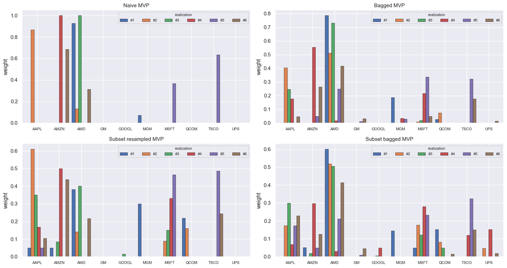

```python
# Same ten stocks as in the introduction
stock_prices = SP500_stocks_2015to2020[tickers].loc["2019":]
X = compute_returns(stock_prices)
mu, Sigma = estimate_parameters(X)

ws = monte_carlo_estimation_error(
    design_funs={
        "Naive MVP": MVP_naive,
        "Bagged MVP": MVP_bagged,
        "Subset resampled MVP": MVP_SSR,
        "Subset bagged MVP": MVP_SSR_bagged,
    },
    mu=mu, Sigma=Sigma, T=len(X),
    num_realizations=6, seed=42, verbose=False,
)

_, axes = plt.subplots(2, 2, figsize=(15, 8))
for ax, (name, W) in zip(axes.ravel(), ws.items()):
    plot_weights(W, assets=list(stock_prices.columns), title=name, ax=ax)
plt.tight_layout()
plt.show()
```

### Naive versus resampled portfolios

We now compute the empirical distribution of the achieved mean--variance objective, as well as the Sharpe ratio, over 1,000 Monte Carlo realizations with $N=50$ stocks. We can observe that the resampled portfolios are more stable and do not suffer from extreme bad realizations (unlike the naive portfolio). However, the naive portfolio can be superior for some realizations.

```python
# Parameters
num_realizations = 1000
N = 50
lookback_months = 12
T_lookback = lookback_months * 21

# Random subset of 50 stocks from 2019 onwards
rng = np.random.default_rng(42)
cols = np.sort(rng.choice(SP500_stocks_2015to2020.shape[1], size=N, replace=False))
stock_prices = SP500_stocks_2015to2020.iloc[:, cols].loc["2019":]

# "True" parameters of the Gaussian model, estimated on the first training window
X_train = compute_returns(stock_prices).iloc[:T_lookback]
mu_true, Sigma_true = estimate_parameters(X_train)
w_clairvoyant = design_MVP(mu_true, Sigma_true, lambda_val=1)

# Monte Carlo over estimation-error realizations
design_funs = {
    "Naive MVP": MVP_naive,
    "Bagged MVP": MVP_bagged,
    "Subset resampled MVP": MVP_SSR,
    "Subset bagged MVP": MVP_SSR_bagged,
}

ws = monte_carlo_estimation_error(design_funs, mu_true, Sigma_true, T=len(X_train),
                                  num_realizations=num_realizations, seed=42, verbose=False)
df = evaluate_portfolios(ws, mu_true, Sigma_true)
```

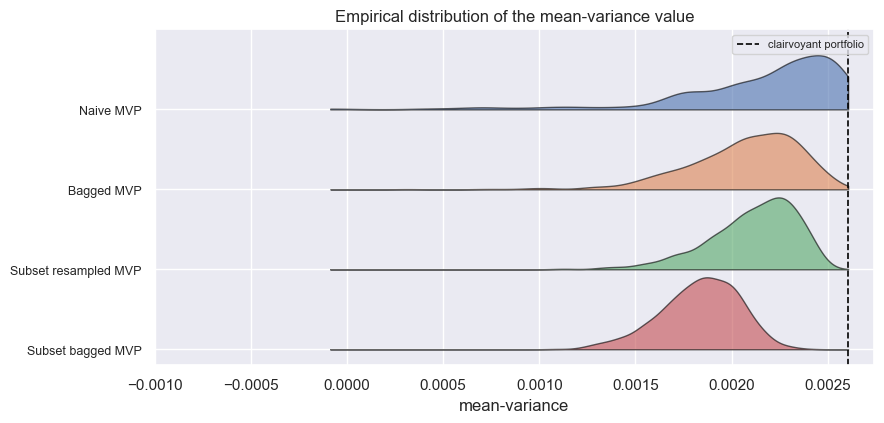

```python
plot_distribution(
    df, x="mean-variance",
    title="Empirical distribution of the mean-variance value",
    xlim=(-0.001, None),
    reference=mean_variance_value(w_clairvoyant, mu_true, Sigma_true),
)
```

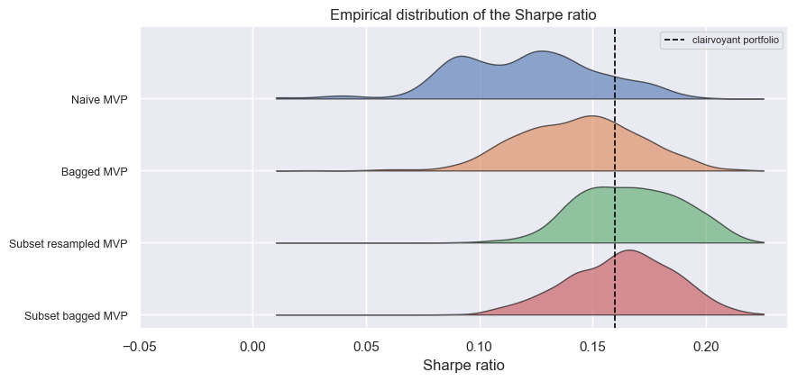

```python
plot_distribution(
    df, x="Sharpe ratio",
    title="Empirical distribution of the Sharpe ratio",
    xlim=(-0.05, None),
    reference=sharpe_ratio(w_clairvoyant, mu_true, Sigma_true),
)
```

### Backtests

Backtest of naive versus resampled mean--variance portfolios (50 stocks from 2017 onwards, six-month lookback, re-optimization every month, daily rebalancing):

```python
N = 50
lookback_months = 6
rng = np.random.default_rng(42)
cols = np.sort(rng.choice(SP500_stocks_2015to2020.shape[1], size=N, replace=False))
stock_prices = SP500_stocks_2015to2020.iloc[:, cols].loc["2017":]

portfolio_funcs = {
    "Naive MVP": MVP_naive,
    "Bagged MVP": MVP_bagged,
    "Subset resampled MVP": MVP_SSR,
    "Subset bagged MVP": MVP_SSR_bagged,
}

returns, weights = backtest(
    portfolio_funcs,
    prices=stock_prices,
    lookback=lookback_months * 21,
    optimize_every=21,
    rebalance_every=1,
    verbose=False,
)
```

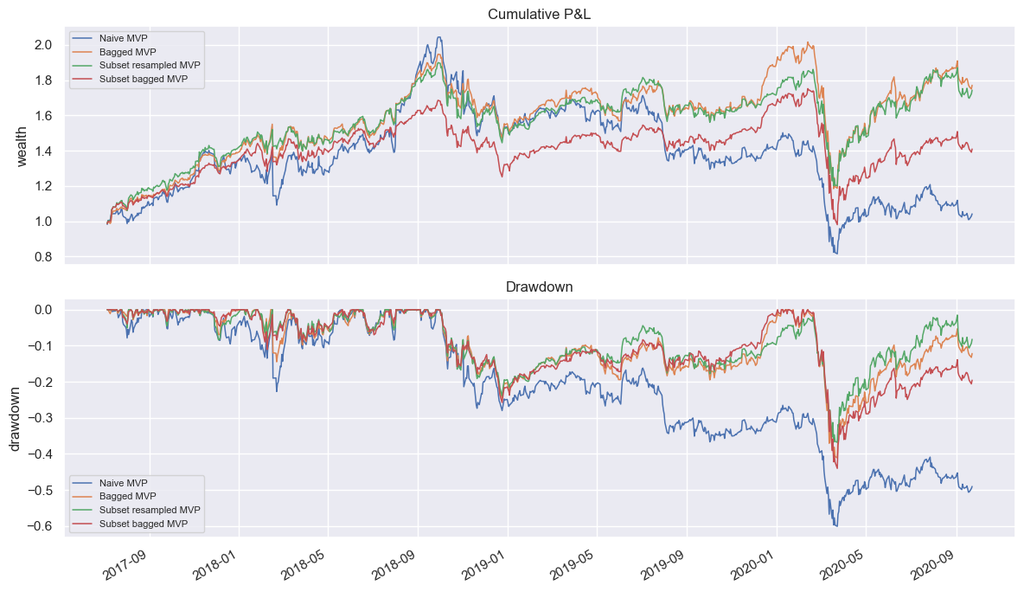

```python
plot_backtest(returns)
```

```python
performance_metrics(returns).style.format({
    "annual return": "{:.2%}",
    "annual volatility": "{:.2%}",
    "Sharpe ratio": "{:.2f}",
    "max drawdown": "{:.2%}",
})
```

|  | annual return | annual volatility | Sharpe ratio | max drawdown |
| --- | --- | --- | --- | --- |
| Naive MVP | 1.29% | 36.26% | 0.22 | -60.10% |
| Bagged MVP | 19.46% | 28.98% | 0.76 | -41.24% |
| Subset resampled MVP | 18.88% | 27.31% | 0.77 | -36.79% |
| Subset bagged MVP | 11.27% | 27.20% | 0.53 | -44.03% |

To be more exhaustive, we now run multiple backtests of the naive versus the resampled mean--variance portfolios on 100 resampled datasets:

```python
datasets = financial_data_resample(
    SP500_stocks_2015to2020,
    num_datasets=100, N_sample=50, T_sample=12 * 21, seed=42,
)

perf = multiple_backtests(
    portfolio_funcs,
    datasets=datasets,
    lookback=6 * 21,
    optimize_every=21,
    rebalance_every=1,
    verbose=False,
)
```

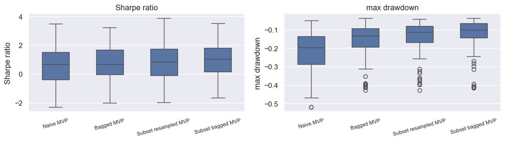

```python
plot_performance_boxplots(perf)
```

# Robust portfolios via skfolio

In the previous sections we used our own implementations of the robust and resampled designs, together with a custom `backtest()` function. The [skfolio](https://skfolio.org/) library offers the same two ideas natively, plus a scikit-learn--compatible backtesting framework, which we showcase here for completeness:

- **Worst-case optimization under mean uncertainty:** the `MeanRisk` optimizer accepts a `mu_uncertainty_set_estimator`, which replaces the expected return $\w^\T\hat{\bmu}$ by its worst-case value over an ellipsoidal uncertainty set. The radius can be calibrated statistically, $\kappa^2 = \chi^2_N(\beta)$, at a given confidence level $\beta$; this is exactly the formulation of the ellipsoidal uncertainty set above, with $\bm{S} = \hat{\bSigma}/T$ and $\kappa = \sqrt{\chi^2_N(\beta)}$. The shape matrix can be taken diagonal (`diagonal=True`) or full (`diagonal=False`).
- **Bootstrap uncertainty sets:** `BootstrapMuUncertaintySet` estimates the shape matrix $\bm{S}$ with a stationary bootstrap instead of the Gaussian approximation, which connects directly with the resampling ideas of the previous section.
- **Distributionally robust optimization:** `DistributionallyRobustCVaR` hedges against the ambiguity in the whole return distribution (a Wasserstein ball around the empirical distribution) rather than against the uncertainty in the mean parameter.

```python
from skfolio.optimization import DistributionallyRobustCVaR, MeanRisk, ObjectiveFunction
from skfolio.measures import RiskMeasure
from skfolio.uncertainty_set import BootstrapMuUncertaintySet, EmpiricalMuUncertaintySet
from skfolio.model_selection import WalkForward, cross_val_predict
from skfolio.population import Population
from skfolio.preprocessing import prices_to_returns
```

As a sanity check, we verify that skfolio's robust `MeanRisk` reproduces our `design_MVP_robust_mu_ellipsoid` when both use the same radius $\kappa = \sqrt{\chi^2_N(0.95)}$ and the same shape matrix $\bm{S} = \hat{\bSigma}/T$. Note that skfolio's utility is $\w^\T\bmu - \lambda\,\w^\T\bSigma\w$, so `risk_aversion=0.5` corresponds to the book's $\lambda/2$ with $\lambda=1$.

```python
# Same 50 stocks from 2017 onwards as in the backtests
rng = np.random.default_rng(42)
cols = np.sort(rng.choice(SP500_stocks_2015to2020.shape[1], size=50, replace=False))
stock_prices = SP500_stocks_2015to2020.iloc[:, cols].loc["2017":]
X_sk = prices_to_returns(stock_prices)

# Training window and statistically calibrated radius
T_trn = 252
X_first = X_sk.iloc[:T_trn]
mu_hat, Sigma_hat = estimate_parameters(X_first)
n_assets = X_sk.shape[1]
kappa_sk = float(np.sqrt(chi2.ppf(0.95, n_assets)))

w_ours = design_MVP_robust_mu_ellipsoid(mu_hat, Sigma_hat, kappa_mu=kappa_sk,
                                        S_mu=Sigma_hat / T_trn, lambda_val=1)

mr_robust_full = MeanRisk(
    objective_function=ObjectiveFunction.MAXIMIZE_UTILITY,
    risk_measure=RiskMeasure.VARIANCE,
    risk_aversion=0.5,
    mu_uncertainty_set_estimator=EmpiricalMuUncertaintySet(confidence_level=0.95, diagonal=False),
).fit(X_first)

print(f"Kappa (chi-squared): {kappa_sk:.3f}")
print(f"Max |difference| between our design and skfolio's: "
      f"{np.abs(mr_robust_full.weights_ - w_ours).max():.2e}")
```

```
Kappa (chi-squared): 8.216
Max |difference| between our design and skfolio's: 1.07e-05
```

```python
optimizers = {
    "Naive MVP": MeanRisk(
        objective_function=ObjectiveFunction.MAXIMIZE_UTILITY,
        risk_measure=RiskMeasure.VARIANCE,
        risk_aversion=0.5,
    ),
    "Robust MVP (ellipsoidal, diagonal)": MeanRisk(
        objective_function=ObjectiveFunction.MAXIMIZE_UTILITY,
        risk_measure=RiskMeasure.VARIANCE,
        risk_aversion=0.5,
        mu_uncertainty_set_estimator=EmpiricalMuUncertaintySet(confidence_level=0.95, diagonal=True),
    ),
    "Robust MVP (ellipsoidal, full)": MeanRisk(
        objective_function=ObjectiveFunction.MAXIMIZE_UTILITY,
        risk_measure=RiskMeasure.VARIANCE,
        risk_aversion=0.5,
        mu_uncertainty_set_estimator=EmpiricalMuUncertaintySet(confidence_level=0.95, diagonal=False),
    ),
    "Robust MVP (bootstrap ellipsoidal)": MeanRisk(
        objective_function=ObjectiveFunction.MAXIMIZE_UTILITY,
        risk_measure=RiskMeasure.VARIANCE,
        risk_aversion=0.5,
        mu_uncertainty_set_estimator=BootstrapMuUncertaintySet(
            confidence_level=0.95, diagonal=False, n_bootstrap_samples=500, seed=42),
    ),
    "DRO CVaR (Wasserstein ball)": DistributionallyRobustCVaR(
        risk_aversion=1.0, cvar_beta=0.95, wasserstein_ball_radius=0.02,
    ),
}

cv = WalkForward(train_size=T_trn, test_size=6 * 21, purged_size=1)
print(f"Number of walk-forward folds: {cv.get_n_splits(X_sk)}")

population = Population([
    cross_val_predict(optimizer, X_sk, cv=cv, portfolio_params=dict(name=name))
    for name, optimizer in optimizers.items()
])
```

```
Number of walk-forward folds: 5
```

### Summary statistics

The `summary()` method reports a long list of risk and performance measures for each portfolio; we display the most relevant ones:

```python
summary = population.summary()
summary.loc[[
    "Annualized Mean",
    "Annualized Standard Deviation",
    "Annualized Sharpe Ratio",
    "MAX Drawdown",
    "Worst Realization",
    "CVaR at 95%",
]]
```

|  | Naive MVP | Robust MVP (ellipsoidal, diagonal) | Robust MVP (ellipsoidal, full) | Robust MVP (bootstrap ellipsoidal) | DRO CVaR (Wasserstein ball) |
| --- | --- | --- | --- | --- | --- |
| Annualized Mean | 11.97% | 12.63% | 7.18% | 7.05% | 11.60% |
| Annualized Standard Deviation | 40.21% | 26.41% | 23.63% | 23.65% | 26.30% |
| Annualized Sharpe Ratio | 0.30 | 0.48 | 0.30 | 0.30 | 0.44 |
| MAX Drawdown | 63.99% | 42.50% | 40.90% | 39.75% | 43.28% |
| Worst Realization | 17.41% | 13.31% | 13.34% | 13.22% | 12.97% |
| CVaR at 95% | 6.41% | 4.23% | 3.82% | 3.81% | 4.19% |

The number of assets effectively used by each design (weights above 0.1%) is not directly available from the summary table, so we compute it explicitly:

```python
cardinality = pd.Series(
    {
        ptf.name: float(np.mean([(sub.weights > 1e-3).sum() for sub in ptf]))
        for ptf in population
    },
    name="average number of active assets",
)
cardinality.round(1)
```

```
Naive MVP                              2.4
Robust MVP (ellipsoidal, diagonal)    40.8
Robust MVP (ellipsoidal, full)        16.2
Robust MVP (bootstrap ellipsoidal)    17.0
DRO CVaR (Wasserstein ball)           44.0
Name: average number of active assets, dtype: float64
```

### Cumulative returns and drawdowns

```python
fig = population.plot_cumulative_returns()
fig.update_layout(
    title="Cumulative returns (out-of-sample)",
    yaxis_title="Cumulative return",
    legend=dict(x=0.02, y=0.98),
)
fig.show()
```

[interactive chart not shown]

```python
fig = population.plot_drawdowns()
fig.update_layout(title="Drawdowns (out-of-sample)")
fig.show()
```

[interactive chart not shown]